# TE_example

# **Example set-up: The user can revise this section**

## **This section illustrates use of the functions**

Additional documentation of the main functions at the top of the **TEMAP2_functions.R**

```r
library(readxl)
library(boot)
library(scales)
library(data.table)
library(ggplot2)
```

## **Read in the data**

```r
setwd("C:/Users/edika/Desktop/key backup/Michael") #working directory
source("TEMAP2_only_functions.R")

data_file<-"Example.xlsx"            # Input data are in a xlsx file

read_excel(data_file, sheet = "Inputs")[, c("Inputs", "Specifications")]
```

```
## # A tibble: 28 x 2
##    Inputs                             Specifications
##    <chr>                              <chr>
##  1 1. Models                          <NA>
##  2 TE-4                               YES
##  3 TE-2                               YES
##  4 TE-1                               YES
##  5 Independence Model                 YES
##  6 <NA>                               <NA>
##  7 2. Fit method                      <NA>
##  8 CHI2 / G2                          CHI2
##  9 <NA>                               <NA>
## 10 3. Parameters for true preferences <NA>
## # ... with 18 more rows
```

```r
read_excel(data_file, sheet = "Participant responses")
```

```
## # A tibble: 2 x 17
##    Case P0000 P0001 P0010 P0011 P0100 P0101 P0110 P0111 P1000 P1001 P1010
##   <dbl> <dbl> <dbl> <dbl> <dbl> <dbl> <dbl> <dbl> <dbl> <dbl> <dbl> <dbl>
## 1    1.    4.    8.    2.    0.    4.   43.    2.    8.    1.    0.    2.
## 2    2.   31.   17.    4.    7.   25.   56.    3.    9.    3.    3.    4.
## # ... with 5 more variables: P1011 <dbl>, P1100 <dbl>, P1101 <dbl>,
## #   P1110 <dbl>, P1111 <dbl>
```

```r
response_patterns <-read_excel(data_file, sheet = "Participant responses")
number_cases <- nrow(response_patterns)
```

```r
simulation_results_list <-TE_READ_DATA(data_file)
```

```
## [1] "Fitting True and Error Model TE-4 for case:  1"
## [1] "Fitting True and Error Model TE-4 for case:  2"
## [1] "Fitting True and Error Model TE-2 for case:  1"
## [1] "Fitting True and Error Model TE-2 for case:  2"
## [1] "Fitting True and Error Model TE-1 for case:  1"
## [1] "Fitting True and Error Model TE-1 for case:  2"
## [1] "Performing Monte Carlo simulations of TE-4 for case:  1"
## [1] "Performing Monte Carlo simulations of TE-4 for case:  2"
## [1] "Performing Monte Carlo simulations of TE-2 for case:  1"
## [1] "Performing Monte Carlo simulations of TE-2 for case:  2"
## [1] "Performing Monte Carlo simulations of TE-1 for case:  1"
## [1] "Performing Monte Carlo simulations of TE-1 for case:  2"
## [1] "All values of t are equal to  2e-06 \n Cannot calculate confidence intervals"
## [1] "Performing Bootstrap simulations of TE-4 for case:  1"
## [1] "All values of t are equal to  2e-06 \n Cannot calculate confidence intervals"
## [1] "All values of t are equal to  2e-06 \n Cannot calculate confidence intervals"
## [1] "Performing Bootstrap simulations of TE-4 for case:  2"
## [1] "Performing Bootstrap simulations of TE-2 for case:  1"
## [1] "All values of t are equal to  0.5 \n Cannot calculate confidence intervals"
## [1] "Performing Bootstrap simulations of TE-2 for case:  2"
## [1] "All values of t are equal to  1e-06 \n Cannot calculate confidence intervals"
## [1] "Performing Bootstrap simulations of TE-1 for case:  1"
## [1] "All values of t are equal to  2e-06 \n Cannot calculate confidence intervals"
## [1] "All values of t are equal to  1e-06 \n Cannot calculate confidence intervals"
## [1] "Performing Bootstrap simulations of TE-1 for case:  2"
## [1] "Performing Monte Carlo Chi-square (or G2) difference test of selected models for case:  1"
## [1] "Performing Monte Carlo Chi-square (or G2) difference test of selected models for case:  2"
```

```r
names(simulation_results_list)
```

```
##  [1] "results_TE_1_errors"  "results_TE_2_errors"  "results_TE_4_errors"
##  [4] "results_Independence" "results_TE_4_MC"      "results_TE_2_MC"
##  [7] "results_TE_1_MC"      "results_TE_4_Boot_CI" "results_TE_2_Boot_CI"
## [10] "results_TE_1_Boot_CI" "user_restrictions"    "fit_method"
## [13] "results_Chi2_diff_MC" "Output_file"
```

```r
(simulation_results_list[[3]])
```

```
## [[1]]
## [[1]]$parameters
##      Estimates
## a_00 0.3321873
## a_01 0.0000020
## a_10 0.0000020
## a_11 0.6678087
##
## [[1]]$errors
##          Estimates
## error_R1 0.2648351
## error_R2 0.5000000
## error_S1 0.5000000
## error_S2 0.0475870
##
## [[1]]$chisq
##   Chi2 statistic
## 1       48.96142
##
## [[1]]$p.value
##   p value, DF= 10
## 1    4.140088e-07
##
## [[1]]$contrast.of.proportions
##       Observed proportions Predicted TE proportions
## P0000          0.037383178               0.04526231
## P0001          0.074766355               0.05245097
## P0010          0.018691589               0.01654720
## P0011          0.000000000               0.02373584
## P0100          0.037383178               0.05245097
## P0101          0.401869159               0.19632594
## P0110          0.018691589               0.02373584
## P0111          0.074766355               0.16761021
## P1000          0.009345794               0.01654720
## P1001          0.000000000               0.02373584
## P1010          0.018691589               0.00620290
## P1011          0.037383178               0.01339153
## P1100          0.009345794               0.02373584
## P1101          0.093457944               0.16761021
## P1110          0.000000000               0.01339153
```

[output cut: 118 more lines]

```
## Replication1_RS'                9
## Replication1_SR'                1
## Replication1_SS'               14
##
## [[2]]$matrix.contrast.frequencies$matrix.of.TE.predictions
##                  Replication2_RR' Replication2_RS' Replication2_SR'
## Replication1_RR'        25.649557        25.696917         5.866380
## Replication1_RS'        25.696917        36.580831         5.913739
## Replication1_SR'         5.866380         5.913739         1.341854
## Replication1_SS'         5.913739        16.797452         1.389212
##                  Replication2_SS'
## Replication1_RR'         5.913739
## Replication1_RS'        16.797452
## Replication1_SR'         1.389212
## Replication1_SS'        12.272880
```

```r
output_file<- paste(simulation_results_list$Output_file,".txt", sep = "")
(fit_method <- simulation_results_list$fit_method)
```

```
## [1] "CHI2"
```

```r
#   It may take 20 min. per case to simulate TE model and analyze 10,000 samples via MC


#   Output is directed to the file designated below

#sink(output_file,append=TRUE)
label_TE_4_errors=c("OUTPUT >>> True and Error Model Results - 4 error terms >>>")
label_TE_2_errors=c("OUTPUT >>> True and Error Model Results - 2 error terms >>>")
label_TE_1_errors=c("OUTPUT >>> True and Error Model Results - 1 error term >>>")
label_Indep=c("OUTPUT >>> Independence Model Results")

print(label_TE_4_errors)
```

```
## [1] "OUTPUT >>> True and Error Model Results - 4 error terms >>>"
```

```r
print(simulation_results_list$results_TE_4_errors)
```

```
## [[1]]
## [[1]]$parameters
##      Estimates
## a_00 0.3321873
## a_01 0.0000020
## a_10 0.0000020
## a_11 0.6678087
##
## [[1]]$errors
##          Estimates
## error_R1 0.2648351
## error_R2 0.5000000
## error_S1 0.5000000
## error_S2 0.0475870
##
## [[1]]$chisq
##   Chi2 statistic
## 1       48.96142
##
## [[1]]$p.value
##   p value, DF= 10
## 1    4.140088e-07
##
## [[1]]$contrast.of.proportions
##       Observed proportions Predicted TE proportions
## P0000          0.037383178               0.04526231
## P0001          0.074766355               0.05245097
## P0010          0.018691589               0.01654720
## P0011          0.000000000               0.02373584
## P0100          0.037383178               0.05245097
## P0101          0.401869159               0.19632594
## P0110          0.018691589               0.02373584
## P0111          0.074766355               0.16761021
## P1000          0.009345794               0.01654720
## P1001          0.000000000               0.02373584
## P1010          0.018691589               0.00620290
## P1011          0.037383178               0.01339153
## P1100          0.009345794               0.02373584
## P1101          0.093457944               0.16761021
## P1110          0.000000000               0.01339153
```

[output cut: 118 more lines]

```
## Replication1_RS'                9
## Replication1_SR'                1
## Replication1_SS'               14
##
## [[2]]$matrix.contrast.frequencies$matrix.of.TE.predictions
##                  Replication2_RR' Replication2_RS' Replication2_SR'
## Replication1_RR'        25.649557        25.696917         5.866380
## Replication1_RS'        25.696917        36.580831         5.913739
## Replication1_SR'         5.866380         5.913739         1.341854
## Replication1_SS'         5.913739        16.797452         1.389212
##                  Replication2_SS'
## Replication1_RR'         5.913739
## Replication1_RS'        16.797452
## Replication1_SR'         1.389212
## Replication1_SS'        12.272880
```

```r
print(label_TE_2_errors)
```

```
## [1] "OUTPUT >>> True and Error Model Results - 2 error terms >>>"
```

```r
print(simulation_results_list$results_TE_2_errors)
```

```
## [[1]]
## [[1]]$parameters
##         Estimates
## a_00 7.849736e-02
## a_01 1.000000e-06
## a_10 1.999999e-06
## a_11 9.214996e-01
##
## [[1]]$errors
##         Estimates
## error_1 0.5000000
## error_2 0.1194666
##
## [[1]]$chisq
##   Chi2 statistic
## 1       63.60579
##
## [[1]]$p.value
##   p value, DF= 12
## 1    4.929884e-09
##
## [[1]]$contrast.of.proportions
##       Observed proportions Predicted TE proportions
## P0000          0.037383178               0.01850388
## P0001          0.074766355               0.02629858
## P0010          0.018691589               0.01850388
## P0011          0.000000000               0.02629858
## P0100          0.037383178               0.02629858
## P0101          0.401869159               0.17889896
## P0110          0.018691589               0.02629858
## P0111          0.074766355               0.17889896
## P1000          0.009345794               0.01850388
## P1001          0.000000000               0.02629858
## P1010          0.018691589               0.01850388
## P1011          0.037383178               0.02629858
## P1100          0.009345794               0.02629858
## P1101          0.093457944               0.17889896
## P1110          0.000000000               0.02629858
## P1111          0.168224299               0.17889896
##
```

[output cut: 114 more lines]

```
## Replication1_RS'                9
## Replication1_SR'                1
## Replication1_SS'               14
##
## [[2]]$matrix.contrast.frequencies$matrix.of.TE.predictions
##                  Replication2_RR' Replication2_RS' Replication2_SR'
## Replication1_RR'        30.957438        30.957438         6.138265
## Replication1_RS'        30.957438        30.957438         6.138265
## Replication1_SR'         6.138265         6.138265         6.516032
## Replication1_SS'         6.138265         6.138265         6.516032
##                  Replication2_SS'
## Replication1_RR'         6.138265
## Replication1_RS'         6.138265
## Replication1_SR'         6.516032
## Replication1_SS'         6.516032
```

```r
print(label_TE_1_errors)
```

```
## [1] "OUTPUT >>> True and Error Model Results - 1 error term >>>"
```

```r
print(simulation_results_list$results_TE_1_errors)
```

```
## [[1]]
## [[1]]$parameters
##      Estimates
## a_00  0.000001
## a_01  0.000002
## a_10  0.000001
## a_11  0.999996
##
## [[1]]$errors
##       Estimates
## error 0.4528992
##
## [[1]]$chisq
##   Chi2 statistic
## 1       251.4935
##
## [[1]]$p.value
##   p value, DF= 13
## 1               0
##
## [[1]]$contrast.of.proportions
##       Observed proportions Predicted TE proportions
## P0000          0.037383178               0.04207336
## P0001          0.074766355               0.05082443
## P0010          0.018691589               0.05082441
## P0011          0.000000000               0.06139568
## P0100          0.037383178               0.05082443
## P0101          0.401869159               0.06139571
## P0110          0.018691589               0.06139568
## P0111          0.074766355               0.07416575
## P1000          0.009345794               0.05082441
## P1001          0.000000000               0.06139568
## P1010          0.018691589               0.06139567
## P1011          0.037383178               0.07416572
## P1100          0.009345794               0.06139568
## P1101          0.093457944               0.07416575
## P1110          0.000000000               0.07416572
## P1111          0.168224299               0.08959192
##
## [[1]]$contrast.of.frequencies
```

[output cut: 112 more lines]

```
## Replication1_RS'                9
## Replication1_SR'                1
## Replication1_SS'               14
##
## [[2]]$matrix.contrast.frequencies$matrix.of.TE.predictions
##                  Replication2_RR' Replication2_RS' Replication2_SR'
## Replication1_RR'         18.40545        14.969690        14.969685
## Replication1_RS'         14.96969        12.175293        12.175284
## Replication1_SR'         14.96969        12.175284        12.175282
## Replication1_SS'         12.17528         9.902521         9.902516
##                  Replication2_SS'
## Replication1_RR'        12.175284
## Replication1_RS'         9.902521
## Replication1_SR'         9.902516
## Replication1_SS'         8.054013
```

```r
print(label_Indep)
```

```
## [1] "OUTPUT >>> Independence Model Results"
```

```r
print(simulation_results_list$results_Independence)
```

```
## [[1]]
## [[1]]$chisq
## [1] 50.17082
##
## [[1]]$Marginal.prob.Independence
##                                    [,1]
## Marginal.prob.Replication1_R  0.6635514
## Marginal.prob.Replication1_S  0.3364486
## Marginal.prob.Replication1_R' 0.1962617
## Marginal.prob.Replication1_S' 0.8037383
## Marginal.prob.Replication2_R  0.6635514
## Marginal.prob.Replication2_S  0.3364486
## Marginal.prob.Replication2_R' 0.1495327
## Marginal.prob.Replication2_S' 0.8504673
##
## [[1]]$contrast.of.frequencies
##       Observed frequencies Predicted TE frequencies
## P0000                    4                1.3826258
## P0001                    8                7.8636840
## P0010                    2                0.7010497
## P0011                    0                3.9872200
## P0100                    4                5.6621817
## P0101                   43               32.2036582
## P0110                    2                2.8709653
## P0111                    8               16.3286154
## P1000                    1                0.7010497
## P1001                    0                3.9872200
## P1010                    2                0.3554618
## P1011                    4                2.0216890
## P1100                    1                2.8709653
## P1101                   10               16.3286154
## P1110                    0                1.4557007
## P1111                   18                8.2792980
##
## [[1]]$matrix.contrast.frequencies
## [[1]]$matrix.contrast.frequencies$matrix.of.frequencies
##                  Replication2_RR' Replication2_RS' Replication2_SR'
## Replication1_RR'                4                8                2
## Replication1_RS'                4               43                2
## Replication1_SR'                1                0                2
```

[output cut: 64 more lines]

```
## Replication1_RS'                9
## Replication1_SR'                1
## Replication1_SS'               14
##
## [[2]]$matrix.contrast.frequencies$matrix.of.Independence.predictions
##                  Replication2_RR' Replication2_RS' Replication2_SR'
## Replication1_RR'        16.218016         25.15872         4.739031
## Replication1_RS'        29.887486         46.36392         8.733356
## Replication1_SR'         5.014781          7.77934         1.465358
## Replication1_SS'         9.241525         14.33621         2.700446
##                  Replication2_SS'
## Replication1_RR'         7.351573
## Replication1_RS'        13.547899
## Replication1_SR'         2.273184
## Replication1_SS'         4.189153
```

```r
print("OUTPUT >>> First few samples parameters for Case 1, Model TE-4 >>>")
```

```
## [1] "OUTPUT >>> First few samples parameters for Case 1, Model TE-4 >>>"
```

```r
print(head(simulation_results_list$results_TE_4_MC[[1]]$parameters_Re.fitted.MC))
```

```
##           a_00  a_01  a_10      a_11
## [1,] 0.1712021 2e-06 1e-06 0.8287949
## [2,] 0.1802167 2e-06 2e-06 0.8197793
## [3,] 0.4017802 1e-06 1e-06 0.5982178
## [4,] 0.4451306 2e-06 2e-06 0.5548654
## [5,] 0.2266210 1e-06 1e-06 0.7733770
## [6,] 0.2529802 2e-06 1e-06 0.7470168
```

```r
print(head(simulation_results_list$results_TE_4_MC[[1]]$errors_Re.fitted.MC))
```

```
##       error_R1  error_R2  error_S1   error_S2
## [1,] 0.2087993 0.3189786 0.5000000 0.14647768
## [2,] 0.1656215 0.2556432 0.5000000 0.10292045
## [3,] 0.2646921 0.5000000 0.4750452 0.06229184
## [4,] 0.3148369 0.4724579 0.4801294 0.00000100
## [5,] 0.2469206 0.5000000 0.5000000 0.10469729
## [6,] 0.3208883 0.4636866 0.4674064 0.05210566
```

```r
print("OUTPUT >>> First few Monte Carlo Re.fitted Chi-squared (or G2) values for Case 1, Model TE-4 >>>")
```

```
## [1] "OUTPUT >>> First few Monte Carlo Re.fitted Chi-squared (or G2) values for Case 1, Model TE-4 >>>"
```

```r
print(head(simulation_results_list$results_TE_4_MC[[1]]$chisq_Re.fitted.MC))
```

```
##      Chi squared statistics of Re-fitted MC
## [1,]                               7.843927
## [2,]                               9.148066
## [3,]                               7.996856
## [4,]                               6.762636
## [5,]                              14.001549
## [6,]                              13.146574
```

```r
print("OUTPUT >>> Chi-squared (or G2) difference test for Case 1, for selected models (available when the Monte Carlo test was not selected) >>>")
```

```
## [1] "OUTPUT >>> Chi-squared (or G2) difference test for Case 1, for selected models (available when the Monte Carlo test was not selected) >>>"
```

```r
print(simulation_results_list$results_Chi2_diff_table[[1]]$TE_1_Chi2_diff_test)
```

```r
print(simulation_results_list$results_Chi2_diff_table[[1]]$TE_2_Chi2_diff_test)
```

```r
print(simulation_results_list$results_Chi2_diff_table[[1]]$TE_4_Chi2_diff_test)
```

```r
print("OUTPUT >>> Monte Carlo Chi-squared (or G2) difference test for Case 1, for selected models >>>")
```

```
## [1] "OUTPUT >>> Monte Carlo Chi-squared (or G2) difference test for Case 1, for selected models >>>"
```

```r
print(simulation_results_list$results_Chi2_diff_MC[[1]]$TE_1_Chi2_diff_test)
```

```
## $Chi2_diff_standard
##   CHI2  - Restricted Model CHI2  - Unrestricted Model
## 1                 251.4935                   9.388984
##   Difference in  CHI2  of Restricted and Unrestricted TE p value, DF= 2
## 1                                               242.1045              0
##
## $Chi2_diff_Re.fitted.MC
## $Chi2_diff_Re.fitted.MC$MC_Re.fitted_chi2_diff_results
##        CHI2 of Re-fitted MC - Restricted Modell
##   [1,]                                17.001568
##   [2,]                                17.265812
##   [3,]                                16.390679
##   [4,]                                 8.542956
##   [5,]                                15.751755
##   [6,]                                 8.181194
```

[output cut: 299 more lines]

```r
print(simulation_results_list$results_Chi2_diff_MC[[1]]$TE_2_Chi2_diff_test)
```

```
## $Chi2_diff_standard
##   CHI2  - Restricted Model CHI2  - Unrestricted Model
## 1                 63.60579                    9.10704
##   Difference in  CHI2  of Restricted and Unrestricted TE p value, DF= 2
## 1                                               54.49875   1.464717e-12
##
## $Chi2_diff_Re.fitted.MC
## $Chi2_diff_Re.fitted.MC$MC_Re.fitted_chi2_diff_results
##        CHI2 of Re-fitted MC - Restricted Modell
##   [1,]                                10.642920
##   [2,]                                27.154260
##   [3,]                                 6.978675
##   [4,]                                 5.560908
##   [5,]                                19.371885
##   [6,]                                11.021711
```

[output cut: 299 more lines]

```r
print(simulation_results_list$results_Chi2_diff_MC[[1]]$TE_4_Chi2_diff_test)
```

```
## $Chi2_diff_standard
##   CHI2  - Restricted Model CHI2  - Unrestricted Model
## 1                 48.96142                   8.675387
##   Difference in  CHI2  of Restricted and Unrestricted TE p value, DF= 2
## 1                                               40.28603   1.786483e-09
##
## $Chi2_diff_Re.fitted.MC
## $Chi2_diff_Re.fitted.MC$MC_Re.fitted_chi2_diff_results
##        CHI2 of Re-fitted MC - Restricted Modell
##   [1,]                                 7.843927
##   [2,]                                 9.148066
##   [3,]                                 7.996856
##   [4,]                                 6.762636
##   [5,]                                14.001549
##   [6,]                                13.146574
```

[output cut: 299 more lines]

```r
#sink(file = NULL)
```

## **Draw histogram of the fit for the TE-4 Model**

## Draw histogram for **Case #1** TE-4 Model **Refit** to each sample

Change to ‘results_TE_2_MC’ for TE-2 model or change to ‘results_TE_1_MC’ for TE-1 model.

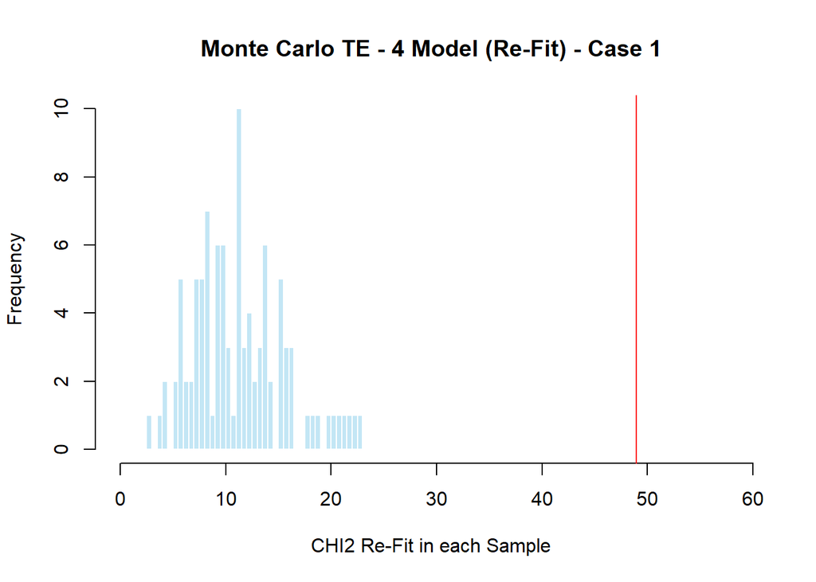

```r
case=1
if (is.null(simulation_results_list$results_TE_4_MC)==0) {
  #pdf("MonteCarlo_TE_4_Refit_Case_1.pdf")
  MonteCarlo_statistic_histogram <- hist(simulation_results_list$results_TE_4_MC[[case]]$chisq_Re.fitted.MC,col=scales::alpha('skyblue',.5),
                                         breaks=50,xlim = c(0, simulation_results_list$results_TE_4_MC[[case]]$original.chisq[[1]]+10),border=F,
                                         main=paste0("Monte Carlo TE - 4 Model (Re-Fit) - Case ", case),
                                         xlab=paste0(fit_method," Re-Fit in each Sample"))
  abline(v=simulation_results_list$results_TE_4_MC[[case]]$original.chisq,col="red")
  #dev.off()

}
```

## Draw histogram for **Case #1** TE Model **Conservative** Monte Carlo

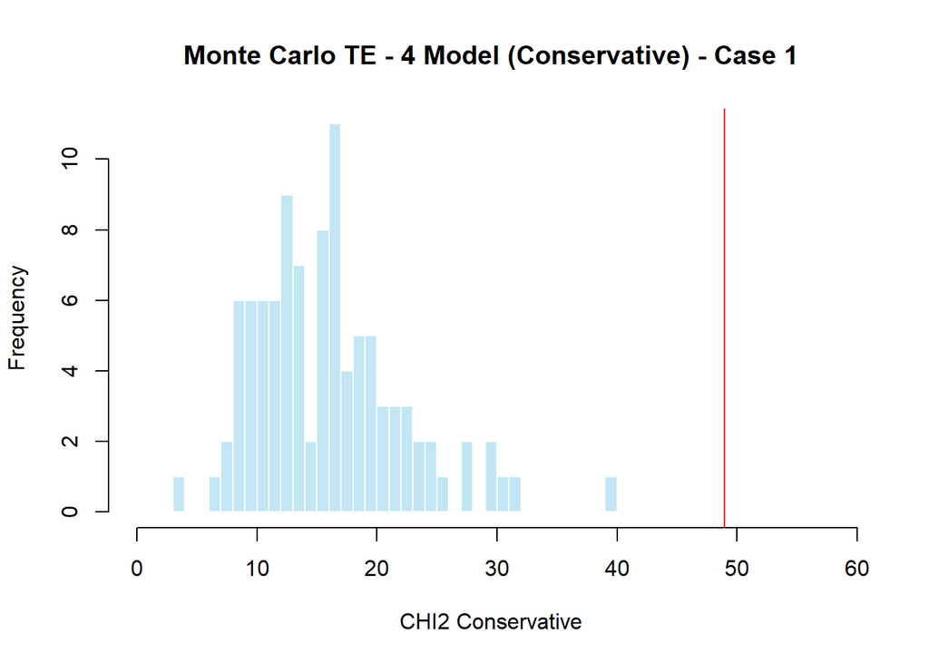

```r
if (is.null(simulation_results_list$results_TE_4_MC)==0) {


  # pdf("MonteCarlo_TE_4_Conservative_Case_1.pdf")
  MonteCarlo_conservative_statistic_histogram <- hist(simulation_results_list$results_TE_4_MC[[case]]$chisq_Conservative.MC,col=scales::alpha('skyblue',.5),
                                                      breaks=50,
                                                      xlim = c(0, simulation_results_list$results_TE_4_MC[[case]]$original.chisq[[1]] +10),
                                                      border=F,
                                                      main=paste0("Monte Carlo TE - 4 Model (Conservative) - Case ", case),
                                                      xlab=paste0(fit_method," Conservative"))
  abline(v=simulation_results_list$results_TE_4_MC[[case]]$original.chisq,col="red")
  #dev.off()
}
```

## **Draw histogram of the fit for the TE-2 Model**

## Draw Histogram for **Case #1** TE-2 Model **Refit** to each sample

Change to ‘results_TE_2_MC’ for TE-2 model or change to ‘results_TE_1_MC’ for TE-1 model.

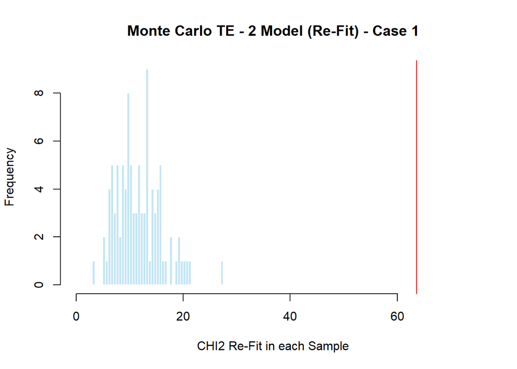

```r
if (is.null(simulation_results_list$results_TE_2_MC)==0) {
  #pdf("MonteCarlo_TE_2_Refit_Case_1.pdf")
  MonteCarlo_statistic_histogram <- hist(simulation_results_list$results_TE_2_MC[[case]]$chisq_Re.fitted.MC,col=scales::alpha('skyblue',.5),
                                         breaks=50,
                                         xlim = c(0, simulation_results_list$results_TE_2_MC[[case]]$original.chisq[[1]]+10),
                                         border=F,
                                         main=paste0("Monte Carlo TE - 2 Model (Re-Fit) - Case ", case),
                                         xlab=paste0(fit_method," Re-Fit in each Sample"))
  abline(v=simulation_results_list$results_TE_2_MC[[case]]$original.chisq,col="red")
  #dev.off()
}
```

## Draw Histogram for **Case #1** TE Model **Conservative** Monte Carlo

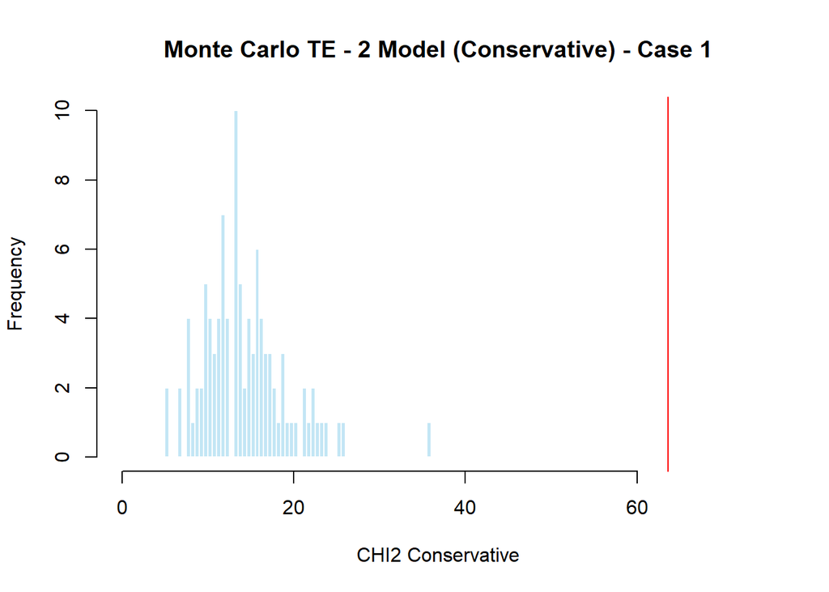

```r
  if (is.null(simulation_results_list$results_TE_2_MC)==0) {

  #pdf("MonteCarlo_TE_2_Conservative_Case_1.pdf")
  MonteCarlo_conservative_statistic_histogram <- hist(simulation_results_list$results_TE_2_MC[[case]]$chisq_Conservative.MC,col=scales::alpha('skyblue',.5),
                                                      breaks=50,
                                                      xlim = c(0, simulation_results_list$results_TE_2_MC[[case]]$original.chisq[[1]]+10),
                                                      border=F,
                                                      main=paste0("Monte Carlo TE - 2 Model (Conservative) - Case ", case),
                                                      xlab=paste0(fit_method," Conservative"))
  abline(v=simulation_results_list$results_TE_2_MC[[case]]$original.chisq,col="red")
  #dev.off()
}
```

## **Save bootstrapped density GRAPHS for the TE-4 Model**

The next section shows how to graph the results of the bootstrapping distributions for Case #1.

Here smoothed density distributions are drawn. One could use histograms instead.

Change to ‘rresults_TE_2_Boot_CI’ for TE-2 model or change to ‘results_TE_1_Boot_CI’ for TE-1 model.

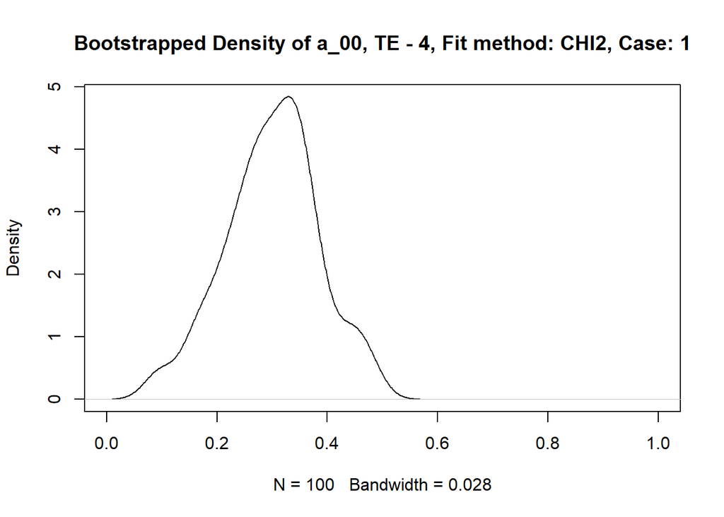

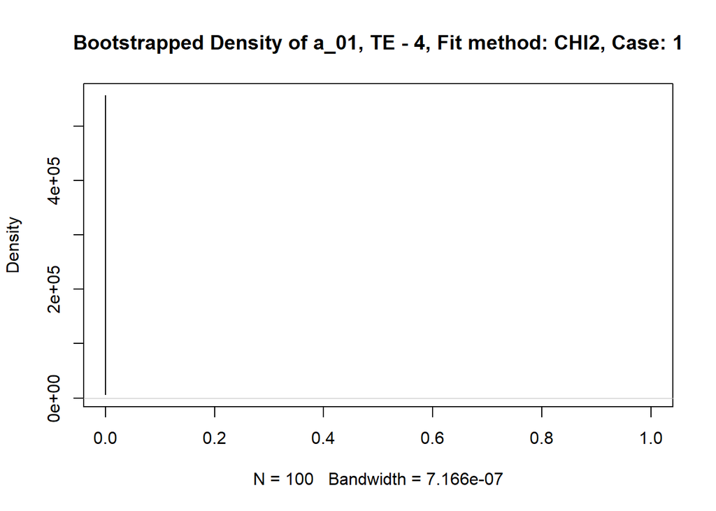

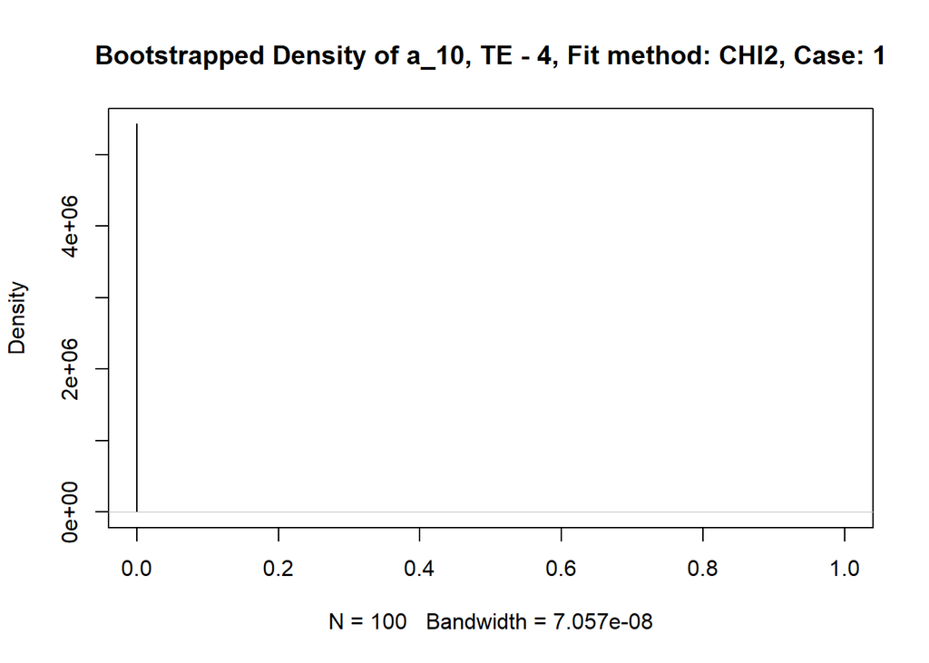

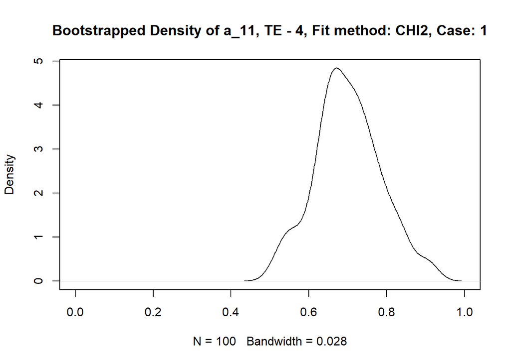

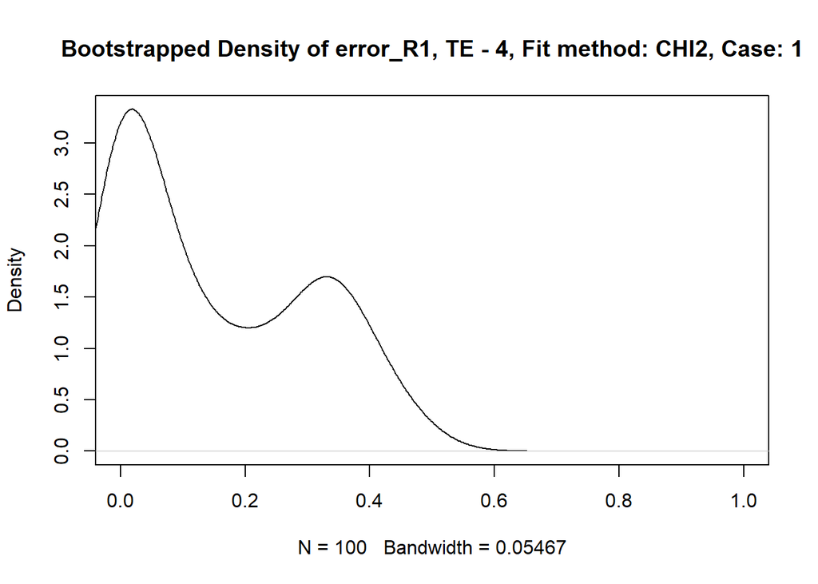

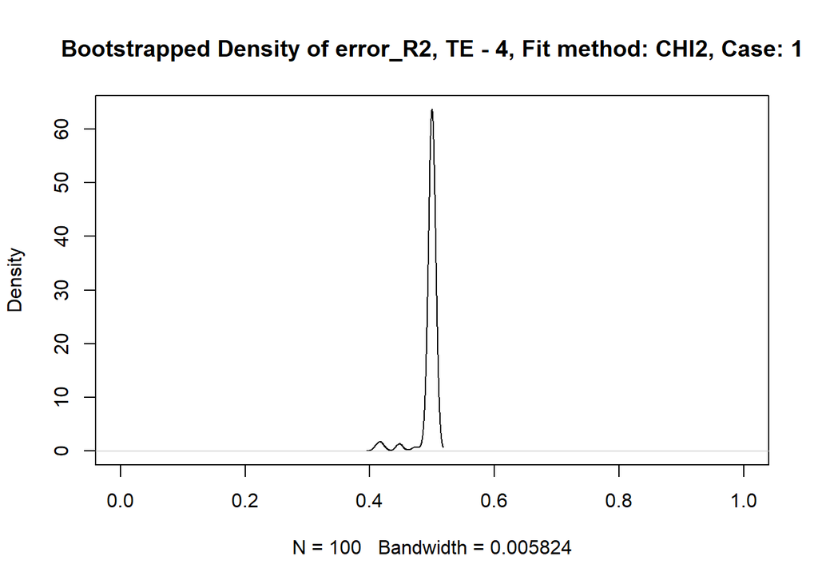

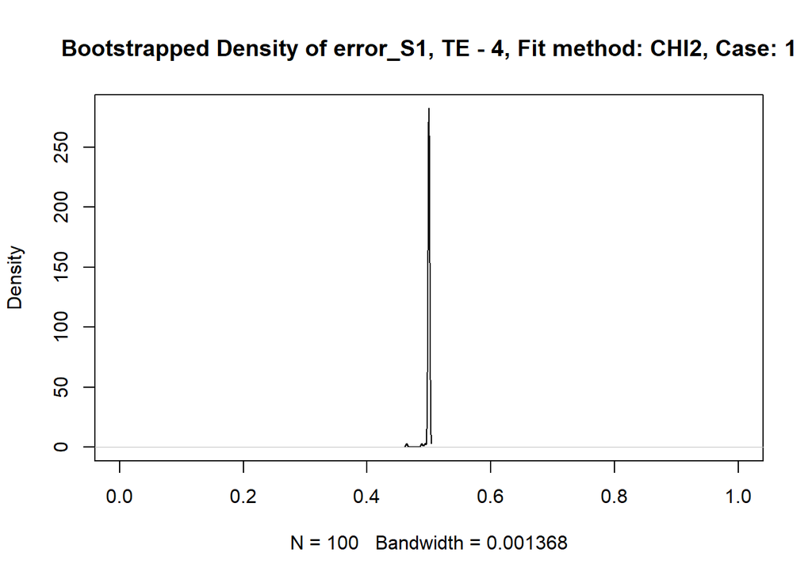

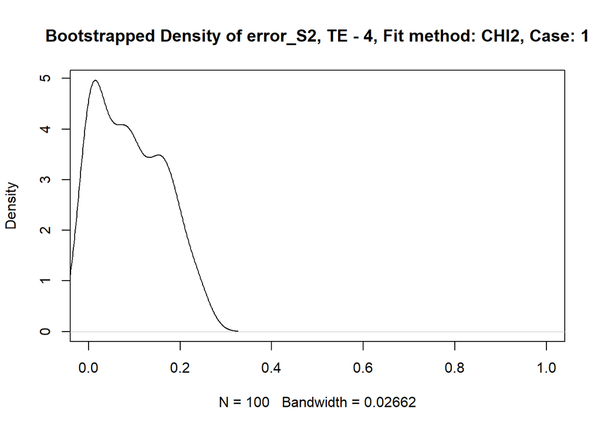

```r
if (is.null(simulation_results_list$results_TE_4_Boot_CI)==0) {
  #pdf("Bootstrapped Density of a_00.pdf")
  plot(density( simulation_results_list$results_TE_4_Boot_CI[[case]]$boot.parameters[,c("a_00")]),xlim = c(0, 1), main=paste0("Bootstrapped Density of a_00, TE - 4, Fit method: ", fit_method, ", Case: ",case))
  #dev.off()
  #pdf("Bootstrapped Density of a_01.pdf")
  plot(density(simulation_results_list$results_TE_4_Boot_CI[[case]]$boot.parameters[,c("a_01")]),xlim = c(0, 1), main=paste0("Bootstrapped Density of a_01, TE - 4, Fit method: ", fit_method, ", Case: ",case))
  #dev.off()
  #pdf("Bootstrapped Density of a_10.pdf")
  plot(density(simulation_results_list$results_TE_4_Boot_CI[[case]]$boot.parameters[,c("a_10")]),xlim = c(0, 1), main=paste0("Bootstrapped Density of a_10, TE - 4, Fit method: ", fit_method, ", Case: ",case))
  #dev.off()
  #pdf("Bootstrapped Density of a_11.pdf")
  plot(density(simulation_results_list$results_TE_4_Boot_CI[[case]]$boot.parameters[,c("a_11")]),xlim = c(0, 1), main=paste0("Bootstrapped Density of a_11, TE - 4, Fit method: ", fit_method, ", Case: ",case))
  #dev.off()
  #pdf("Bootstrapped Density of error_R1.pdf")
  plot(density(simulation_results_list$results_TE_4_Boot_CI[[case]]$boot.errors[,c("error_R1")]),xlim = c(0, 1), main=paste0("Bootstrapped Density of error_R1, TE - 4, Fit method: ", fit_method, ", Case: ",case))
  #dev.off()
  #pdf("Bootstrapped Density of error_R2.pdf")
  plot(density(simulation_results_list$results_TE_4_Boot_CI[[case]]$boot.errors[,c("error_R2")]),xlim = c(0, 1), main=paste0("Bootstrapped Density of error_R2, TE - 4, Fit method: ", fit_method, ", Case: ",case))
  #dev.off()
  #pdf("Bootstrapped Density of error_S1.pdf")
  plot(density(simulation_results_list$results_TE_4_Boot_CI[[case]]$boot.errors[,c("error_S1")]),xlim = c(0, 1), main=paste0("Bootstrapped Density of error_S1, TE - 4, Fit method: ", fit_method, ", Case: ",case))
  #dev.off()
  #pdf("Bootstrapped Density of error_S2.pdf")
  plot(density(simulation_results_list$results_TE_4_Boot_CI[[case]]$boot.errors[,c("error_S2")]),xlim = c(0, 1), main=paste0("Bootstrapped Density of error_S2, TE - 4, Fit method: ", fit_method, ", Case: ",case))
  #dev.off()
}
```

## **Save bootstrapped density graphs for the TE-2 Model**

The next section shows how to graph the results of the bootstrapping distributions for Case #1

Here smoothed density distributions are drawn. One could use histograms instead.

Change to ‘rresults_TE_2_Boot_CI’ for TE-2 model or change to ‘results_TE_1_Boot_CI’ for TE-1 model.

[figure not shown]

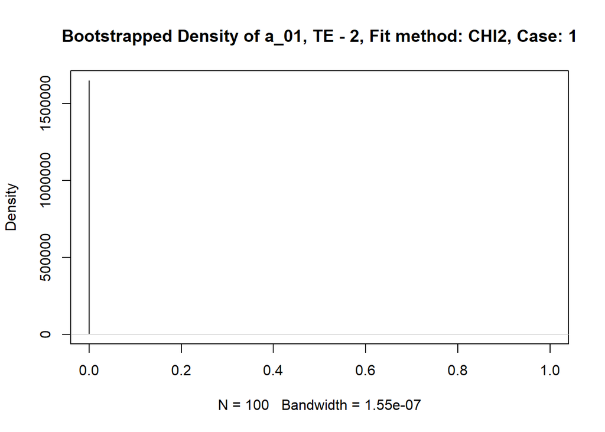

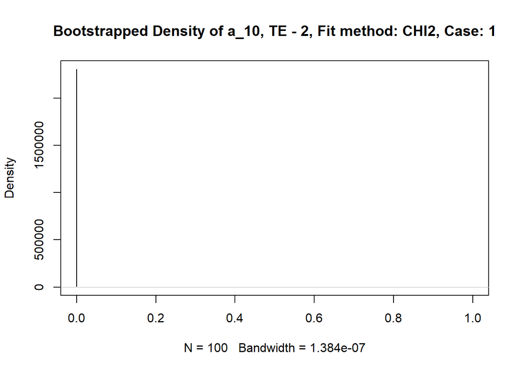

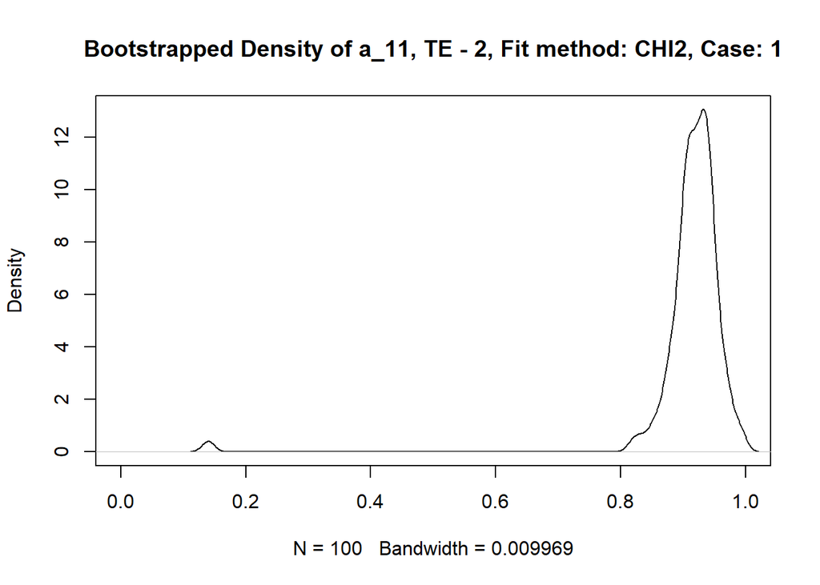

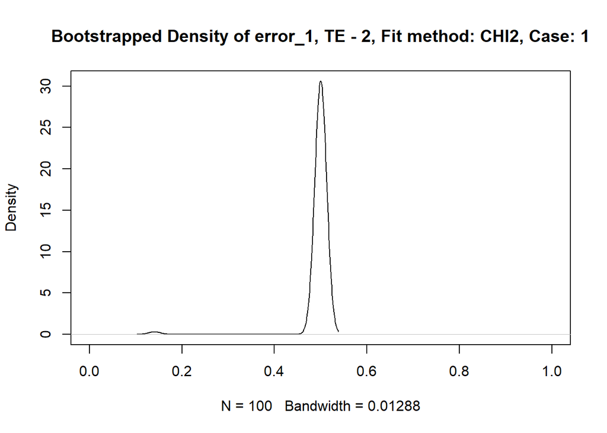

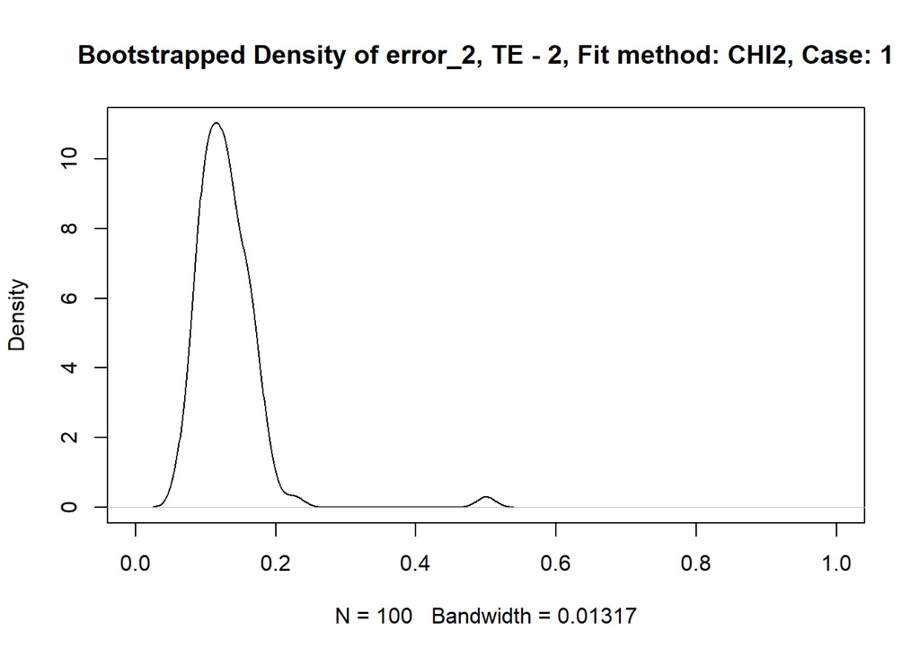

```r
#dev.set(dev.next())
#dev.cur()

if (is.null(simulation_results_list$results_TE_2_Boot_CI)==0) {

  #pdf("TE-2 Bootstrapped Density of a_00.pdf")
  plot(( simulation_results_list$results_TE_2_Boot_CI[[1]]$boot.parameters[,c("a_00")]),xlim = c(0, 1), main=paste0("Bootstrapped Density of a_00, TE - 2, Fit method: ", fit_method, ", Case: ",case))
  # dev.off()
  #pdf("TE-2 Bootstrapped Density of a_01.pdf")
  plot(density(simulation_results_list$results_TE_2_Boot_CI[[1]]$boot.parameters[,c("a_01")]),xlim = c(0, 1), main=paste0("Bootstrapped Density of a_01, TE - 2, Fit method: ", fit_method, ", Case: ",case))
  #dev.off()
  #pdf("TE-2 Bootstrapped Density of a_10.pdf")
  plot(density(simulation_results_list$results_TE_2_Boot_CI[[1]]$boot.parameters[,c("a_10")]),xlim = c(0, 1), main=paste0("Bootstrapped Density of a_10, TE - 2, Fit method: ", fit_method, ", Case: ",case))
  #dev.off()
  #pdf("TE-2 Bootstrapped Density of a_11.pdf")
  plot(density(simulation_results_list$results_TE_2_Boot_CI[[1]]$boot.parameters[,c("a_11")]),xlim = c(0, 1), main=paste0("Bootstrapped Density of a_11, TE - 2, Fit method: ", fit_method, ", Case: ",case))
  #dev.off()
  #pdf("TE-2 Bootstrapped Density of error_1.pdf")
  plot(density(simulation_results_list$results_TE_2_Boot_CI[[1]]$boot.errors[,c("error_1")]),xlim = c(0, 1), main=paste0("Bootstrapped Density of error_1, TE - 2, Fit method: ", fit_method, ", Case: ",case))
  #dev.off()
  #pdf("TE-2 Bootstrapped Density of error_2.pdf")
  plot(density(simulation_results_list$results_TE_2_Boot_CI[[1]]$boot.errors[,c("error_2")]),xlim = c(0, 1), main=paste0("Bootstrapped Density of error_2, TE - 2, Fit method: ", fit_method, ", Case: ",case))
  #dev.off()

}
```

## **Draw histograms of the Chi-squared difference test for the restricted and unrestricted models**

## Draw Histogram for **Case #1** of the Chi-squared difference values for the TE-4 Model

Change participant in ‘[[case]]’.

```r
TE_4_Re_fit <- simulation_results_list$results_Chi2_diff_MC[[case]]$TE_4_Chi2_diff_test$Chi2_diff_Re.fitted.MC$MC_Re.fitted_chi2_diff_results[,3]
TE_2_Re_fit <- simulation_results_list$results_Chi2_diff_MC[[case]]$TE_2_Chi2_diff_test$Chi2_diff_Re.fitted.MC$MC_Re.fitted_chi2_diff_results[,3]
TE_1_Re_fit <- simulation_results_list$results_Chi2_diff_MC[[case]]$TE_1_Chi2_diff_test$Chi2_diff_Re.fitted.MC$MC_Re.fitted_chi2_diff_results[,3]

TE_4_Standard <- simulation_results_list$results_Chi2_diff_MC[[case]]$TE_4_Chi2_diff_test$Chi2_diff_standard[,3]
TE_2_Standard <- simulation_results_list$results_Chi2_diff_MC[[case]]$TE_2_Chi2_diff_test$Chi2_diff_standard[,3]
TE_1_Standard <- simulation_results_list$results_Chi2_diff_MC[[case]]$TE_1_Chi2_diff_test$Chi2_diff_standard[,3]
```

Adjust the number of breaks for a better display

Negative differences in Chi2 could occur in rare occasions, only when the optimization algorithm reaches local minima points.

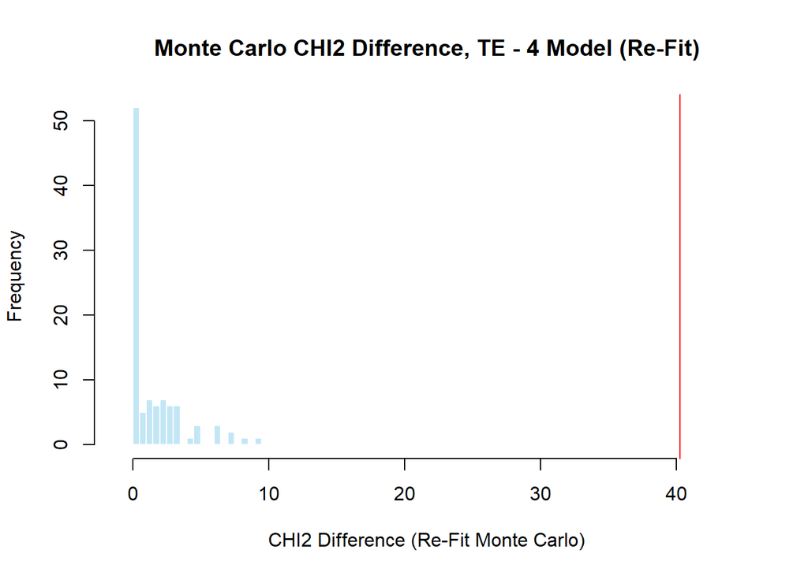

```r
if (is.null(TE_4_Re_fit)==0) {
  #pdf(paste0("MonteCarlo_",fit_method,"_difference_test_TE_4_Refit_Case_",case, ".pdf"))
  MonteCarlo_histogram <- hist(TE_4_Re_fit,col=scales::alpha('skyblue',.5),breaks=30,
                               border=F,
                               main=paste0("Monte Carlo ",fit_method," Difference, TE - 4 Model (Re-Fit)"),
                               xlim = c(-1, TE_4_Standard+4),
                               xlab=paste0(fit_method," Difference (Re-Fit Monte Carlo)"))
  abline(v=TE_4_Standard,col="red")
  #dev.off()
}
```

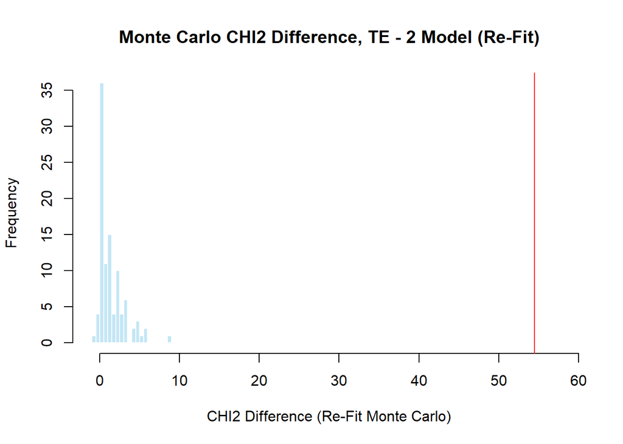

```r
if (is.null(TE_2_Re_fit)==0) {
  #pdf(paste0("MonteCarlo_",fit_method,"_difference_test_TE_2_Refit_Case_",case, ".pdf"))
  MonteCarlo_histogram <- hist(TE_2_Re_fit,col=scales::alpha('skyblue',.5),breaks=30,
                               border=F,
                               main=paste0("Monte Carlo ",fit_method," Difference, TE - 2 Model (Re-Fit)"),
                               xlim = c(-1, TE_2_Standard+4),
                               xlab=paste0(fit_method," Difference (Re-Fit Monte Carlo)"))
  abline(v=TE_2_Standard,col="red")
  #dev.off()
}
```

This example is set up to save only selected results to illustrate the program

For example, it saves only graphs for the first case.

You can easily revise it to save other information and to make other graphs

See documentation section.

# **For profesoor Lee**

```r
fit_method <- simulation_results_list$fit_method
if (is.null(simulation_results_list$results_TE_4_Boot_CI)==0) {

  file_name <- paste0("Boot sample estimates, TE4, fit method ", fit_method,
                      " restrictions a_00=",simulation_results_list$user_restrictions[1],
                      " ,a_01=",simulation_results_list$user_restrictions[2],
                      " ,a_10=",simulation_results_list$user_restrictions[3],
                      " ,a_11=",simulation_results_list$user_restrictions[4],
                      ".csv")

  boot_estimates_all <- NULL
  for (i in 1:length(simulation_results_list$results_TE_4_Boot_CI)) {
    boot_estimates<- as.data.table(simulation_results_list$results_TE_4_Boot_CI[[i]]$boot.parameters)
    boot_estimates <- cbind(boot_estimates,simulation_results_list$results_TE_4_Boot_CI[[i]]$boot.errors)

    boot_estimates[,case:=i]

    boot_estimates_all <- rbind(boot_estimates_all, boot_estimates)
  }

  write.csv(boot_estimates_all, file= file_name)


}


if (is.null(simulation_results_list$results_TE_2_Boot_CI)==0) {


  file_name <- paste0("Boot sample estimates, TE2, fit method ", fit_method, " restrictions a_00=",simulation_results_list$user_restrictions[1],
                      " ,a_01=",simulation_results_list$user_restrictions[2],
                      " ,a_10=",simulation_results_list$user_restrictions[3],
                      " ,a_11=",simulation_results_list$user_restrictions[4],
                      ".csv")

  boot_estimates_all <- NULL
  for (i in 1:length(simulation_results_list$results_TE_2_Boot_CI)) {
    boot_estimates<- as.data.table(simulation_results_list$results_TE_2_Boot_CI[[i]]$boot.parameters)
    boot_estimates <- cbind(boot_estimates,simulation_results_list$results_TE_2_Boot_CI[[i]]$boot.errors)

    boot_estimates[,case:=i]

    boot_estimates_all <- rbind(boot_estimates_all, boot_estimates)
  }

  write.csv(boot_estimates_all, file= file_name)

}



if (is.null(simulation_results_list$results_TE_1_Boot_CI)==0) {


  file_name <- paste0("Boot sample estimates, TE1, fit method ", fit_method, " restrictions a_00=",simulation_results_list$user_restrictions[1],
                      " ,a_01=",simulation_results_list$user_restrictions[2],
                      " ,a_10=",simulation_results_list$user_restrictions[3],
                      " ,a_11=",simulation_results_list$user_restrictions[4],
                      ".csv")

  boot_estimates_all <- NULL
  for (i in 1:length(simulation_results_list$results_TE_1_Boot_CI)) {
    boot_estimates<- as.data.table(simulation_results_list$results_TE_1_Boot_CI[[i]]$boot.parameters)
    boot_estimates <- cbind(boot_estimates,simulation_results_list$results_TE_1_Boot_CI[[i]]$boot.errors)

    boot_estimates[,case:=i]

    boot_estimates_all <- rbind(boot_estimates_all, boot_estimates)
  }

  write.csv(boot_estimates_all, file= file_name)

}
```

# Plot of confidence intervals

Confidence intervals are ommited for the parameters constrained to be 0 in the input file

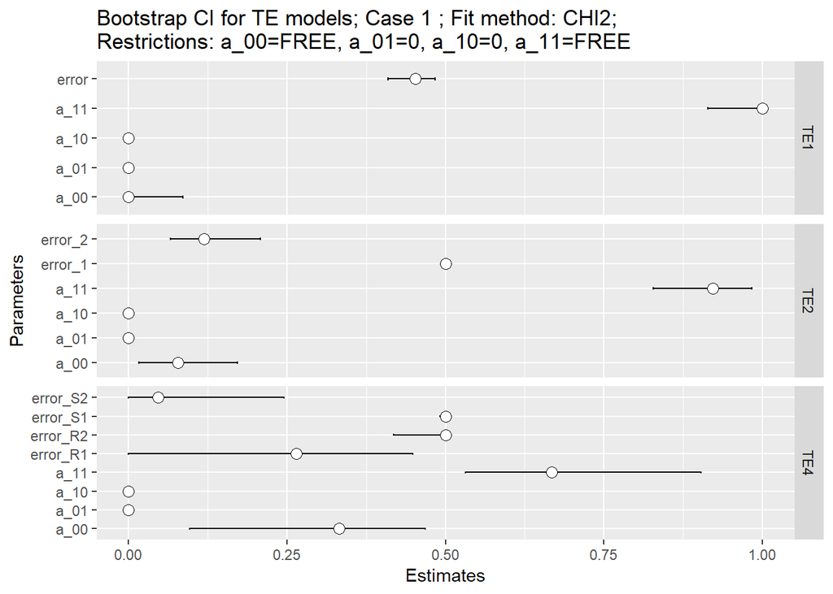

```r
case=1 #select case for graph

CI_plot_TE1 <-NULL
CI_plot_TE2 <-NULL
CI_plot_TE4 <-NULL

if (is.null(simulation_results_list$results_TE_1_Boot_CI)==0) {

  CI_plot_TE1<-(simulation_results_list$results_TE_1_Boot_CI[[case]]$confidence.intervals)
  CI_plot_TE1 <-cbind(Parameters=rownames(CI_plot_TE1), CI_plot_TE1)
  CI_plot_TE1 <- as.data.table(CI_plot_TE1)
  CI_plot_TE1[,Estimates:=as.numeric(Estimates)]
  CI_plot_TE1[,`Lower bound`:=as.numeric(`Lower bound`)]
  CI_plot_TE1[,`Upper bound`:=as.numeric(`Upper bound`)]
  CI_plot_TE1[,Model:= "TE1"]
}

if (is.null(simulation_results_list$results_TE_2_Boot_CI)==0) {


  CI_plot_TE2<-(simulation_results_list$results_TE_2_Boot_CI[[case]]$confidence.intervals)
  CI_plot_TE2<-cbind(Parameters=rownames(CI_plot_TE2), CI_plot_TE2)
  CI_plot_TE2 <- as.data.table(CI_plot_TE2)
  CI_plot_TE2[,Estimates:=as.numeric(Estimates)]
  CI_plot_TE2[,`Lower bound`:=as.numeric(`Lower bound`)]
  CI_plot_TE2[,`Upper bound`:=as.numeric(`Upper bound`)]
  CI_plot_TE2[,Model:= "TE2"]
}

if (is.null(simulation_results_list$results_TE_4_Boot_CI)==0) {


  CI_plot_TE4<-(simulation_results_list$results_TE_4_Boot_CI[[case]]$confidence.intervals)
  CI_plot_TE4<-cbind(Parameters=rownames(CI_plot_TE4), CI_plot_TE4)
  CI_plot_TE4 <- as.data.table(CI_plot_TE4)
  CI_plot_TE4[,Estimates:=as.numeric(Estimates)]
  CI_plot_TE4[,`Lower bound`:=as.numeric(`Lower bound`)]
  CI_plot_TE4[,`Upper bound`:=as.numeric(`Upper bound`)]
  CI_plot_TE4[,Model:= "TE4"]
}

CI_plot_all <- rbind(CI_plot_TE1, CI_plot_TE2, CI_plot_TE4)

# Make the graph with the 95% confidence interval
if (is.null(CI_plot_all)!=1) {

  figure <- ggplot(CI_plot_all, aes(x=Parameters,
                                    y=Estimates #, group=1
                                    #ymin=CI_plot$`Lower bound`, ymax=CI_plot$`Upper bound`
  )) +
    geom_errorbar(width=.1, aes(ymin=CI_plot_all$`Lower bound`, ymax=CI_plot_all$`Upper bound`)) +
    geom_point(shape=21, size=3, fill="white")  +  coord_flip() +
    facet_grid( Model~., scales = "free") +
    ggtitle(paste0("Bootstrap CI for TE models; Case ",case," ; Fit method: ", fit_method,
                   ";\nRestrictions: a_00=",simulation_results_list$user_restrictions[1],
                   ", a_01=",simulation_results_list$user_restrictions[2],
                   ", a_10=",simulation_results_list$user_restrictions[3],
                   ", a_11=",simulation_results_list$user_restrictions[4]
    ))
  ggsave(figure, file= paste0("Bootstrap CI for TE models; Case ",case," ; Fit method= ", fit_method,
                              "; Restrictions a_00=",simulation_results_list$user_restrictions[1],
                              ", a_01=",simulation_results_list$user_restrictions[2],
                              ", a_10=",simulation_results_list$user_restrictions[3],
                              ", a_11=",simulation_results_list$user_restrictions[4], ".pdf"  ), width=7,height=8)
  figure
}
```